# EDA.Rmd

# EDA Autism spectrum discorder quiz

## Introduction

The AQ-10 test is a test with 10 questions that will try and predict if you have the autism spectrum disorder. Each question has 4 anwsers. Slightly agree, Agree, Slightly disagree and disagree. Every question gives either 1 or 0 points based on the anwser. Slightly agree gives the same points as agree and the same for disagree. They made it like this to make it feel like slightly agree/disagree feels like a better anwser when in doubt. The more points the people have, the more chance there is of them having ADS (Autism disorder spectrum).

The data: https://www.kaggle.com/datasets/faizunnabi/autism-screening

## Research question

#### How accurate can the AQ-10 test predict whether someone has the autism spectrum disorder?

The goal of this research question is to find out if this autism spectrum disorder test actually works and predicts someone has it. This would involve machine learning by testing if the computer would find correlations and would be able to predict them actually having ASD, which the test does aswell. This way the accuracy of the test can be measured.

We will start off by looking at the data and codebook. The data contains 21 variables which will be loaded in as the codebook.

| Variable.name.short | Variable.name.human.readable | description | type | unit |
| --- | --- | --- | --- | --- |
| a1_score | Anwser question 1 score | The first anwser of the Q10 test | numeric 1 or 0 | score |
| a2_score | Anwser question 2 score | The second anwser of the Q10 test | numeric 1 or 0 | score |
| a3_score | Anwser question 3 score | The third anwser of the Q10 test | numeric 1 or 0 | score |
| a4_score | Anwser question 4 score | The fourth anwser of the Q10 test. numeric 1 or 0 | score |  |
| a5_score | Anwser question 5 score | The fifth anwser of the Q10 test | numeric 1 or 0 | score |
| a6_score | Anwser question 6 score | The sixth anwser of the Q10 test | numeric 1 or 0 | score |
| a7_score | Anwser question 7 score | The seventh anwser of the Q10 test | numeric 1 or 0 | score |
| a8_score | Anwser question 8 score | The eighth anwser of the Q10 test | numeric 1 or 0 | score |
| a9_score | Anwser question 9 score | The ningth anwser of the Q10 test | numeric 1 or 0 | score |
| a10_score | Anwser question 10 score | The tenth anwser of the Q10 test | numeric 1 or 0 | score |
| age | age | The age of the corresponding person | numeric | years |
| gender | gender | The gender of the corresponding person | nominal | male or female |
| ethnicity | ethnicity | the ethnicity of the corresponding person nominal | type of ethnicity |  |
| jaundice | jaundice | Does the person have jaundice.This is sometimes linked with ASD | boolean | yes or no |
| autism | autism | Does the person actually have autism | boolean | yes or no |
| country_of_r | country of residence | The country where the corresponding person lives | nominal | country name |
| used_app_before | used the app before | Did the corresponding person used the app that is used to take the Q10 test before | boolean | yes or no |
| end_score | final test score | The score of all 10 questions added up to eachother | numeric | 0-10 score |
| age_desc | age descending | The age of the person in a string. Usually 18 older | nominal factor | years |
| relation | relationship | relation user compared to person of interest | nominal | string of relationship |
| class_asd | family member with asd | Does a corresponding person’s family member have ASD | boolean | yes or no |

## The data

This is the data that will be used in the following project. it contains various information about adults doing an autism test. The columns speak for themselves except for the first 10. These columns represent the anwsers of the following question list.

https://www.nice.org.uk/guidance/cg142/resources/autism-spectrum-quotient-aq10-test-pdf-186582493

After knowing all of this it’s time to see if the data is right. The data is supposed to have 21 columns and 704 rows.

```
## [1] 21
```

```
## [1] 704
```

## Checking the data

The data also needs to be checked of missing data (A row that’s missing certain values). The ones that are missing important data will be removed. This needs to be done in order to not mess everything up. For example if someone is missing an anwser of the quiz, their score will be messed up and invalid.

This code will check if there are invalid values in any column.

```r
data[data == "?"] <- NA
data[1:11] <- data[1:11] %>% mutate_if(is.character,as.numeric) # Changing strings that are numbers to numbers

# Changing the 0,1 to NO and YES. The no means they dont get a point and the yes means they did.
data[1:10][data[1:10] == 0] <- "NO"
data[1:10][data[1:10] == 1] <- "YES"

summary(data)
```

```
##    a1_score           a2_score           a3_score           a4_score
##  Length:704         Length:704         Length:704         Length:704
##  Class :character   Class :character   Class :character   Class :character
##  Mode  :character   Mode  :character   Mode  :character   Mode  :character
##
##
##
##
##    a5_score           a6_score           a7_score           a8_score
##  Length:704         Length:704         Length:704         Length:704
##  Class :character   Class :character   Class :character   Class :character
##  Mode  :character   Mode  :character   Mode  :character   Mode  :character
##
##
##
##
##    a9_score          a10_score              age           gender
##  Length:704         Length:704         Min.   : 17.0   Length:704
##  Class :character   Class :character   1st Qu.: 21.0   Class :character
##  Mode  :character   Mode  :character   Median : 27.0   Mode  :character
##                                        Mean   : 29.7
##                                        3rd Qu.: 35.0
##                                        Max.   :383.0
##                                        NA's   :2
##   ethnicity           jaundice            autism          country_of_r
##  Length:704         Length:704         Length:704         Length:704
##  Class :character   Class :character   Class :character   Class :character
##  Mode  :character   Mode  :character   Mode  :character   Mode  :character
##
##
##
##
##  used_app_before      end_score        age_desc           relation
##  Length:704         Min.   : 0.000   Length:704         Length:704
##  Class :character   1st Qu.: 3.000   Class :character   Class :character
##  Mode  :character   Median : 4.000   Mode  :character   Mode  :character
##                     Mean   : 4.875
##                     3rd Qu.: 7.000
##                     Max.   :10.000
##
##   class_asd
##  Length:704
##  Class :character
##  Mode  :character
##
##
##
##
```

There are two NA’s in the data. It is important to remove those in order to keep the data balanced. This will be done by removing their rows.

```r
data <- data[-c(which(is.na(data$age))), ]
```

We will now take a look at the ages of the people taking the test are.

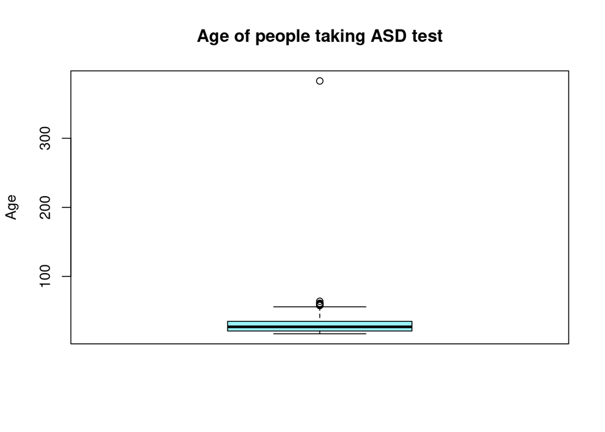

```r
boxplot(data$age, main="Age of people taking ASD test", ylab="Age", col="cadetblue1")
```

Figure 1A, As the boxplot shows, there’s one huge outlier. One person would be 383 years old which just isn’t humanly possible. The solution to this is taking out the whole row.

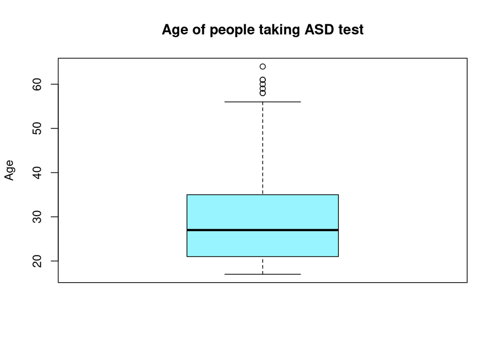

```r
data <- data[-c(which(data$age == 383)),]
boxplot(data$age, main="Age of people taking ASD test", ylab="Age", col="cadetblue1")
```

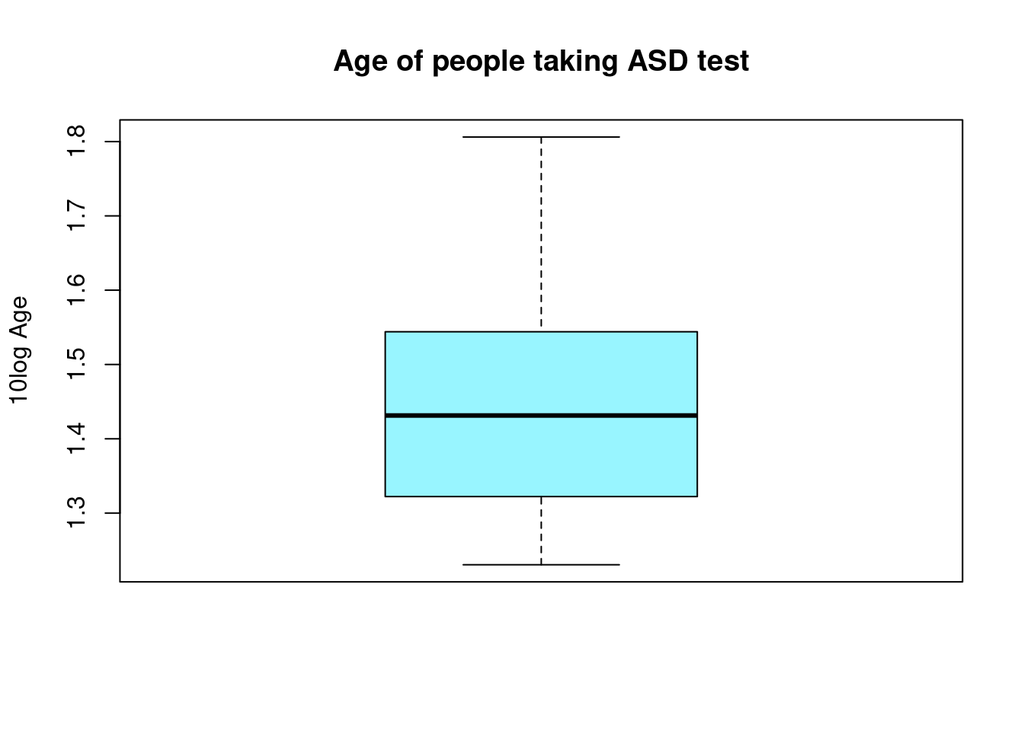

```r
boxplot(log10(data$age), main="Age of people taking ASD test", ylab="10log Age", col="cadetblue1")
```

Figure 1B/C, This is the fixed plot by using the 10log function. It shows that the majority of the people taking the test is Mid age.

## Correlations

This boxplot shows that there’s not much old people (60+) doing the test. The people who take this test are usually mid aged.

Now we will take a look at the test, how much people had what kind of anwser. The goal of this plot is to take a look at what the people scored.

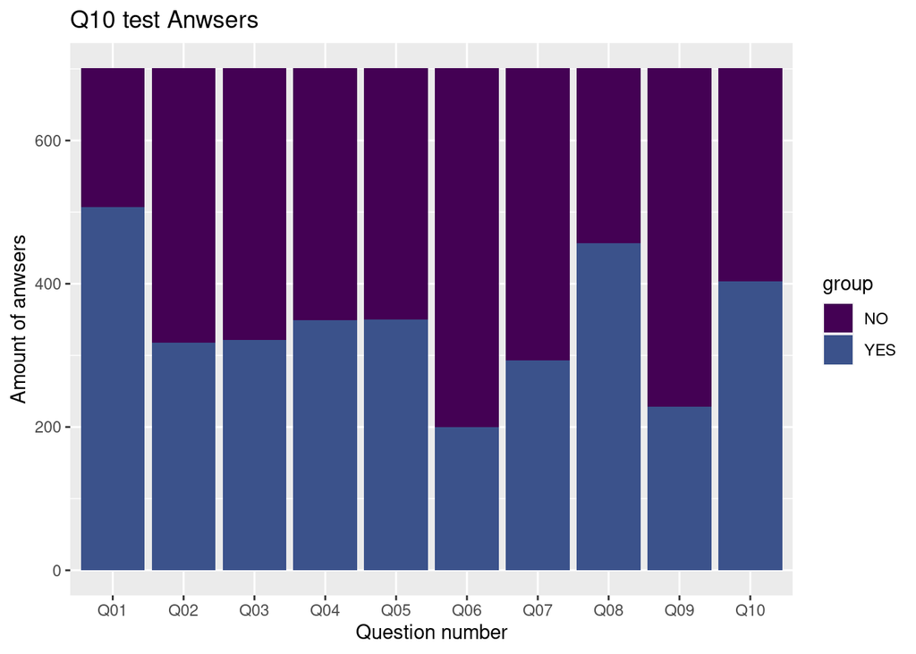

```r
df <- data.frame(x = rep(paste0("Q", c("01", "02", "03", "04", "05", "06", "07", "08", "09", "10")), each = 2),
                   y = rep(0, each=20),
                   group = rep(c("YES", "NO"), time = 10))

df$y[1] <- sum(data$a1_score == "YES")
df$y[2] <- sum(data$a1_score == "NO")

df$y[3] <- sum(data$a2_score == "YES")
df$y[4] <- sum(data$a2_score == "NO")

df$y[5] <- sum(data$a3_score == "YES")
df$y[6] <- sum(data$a3_score == "NO")

df$y[7] <- sum(data$a4_score == "YES")
df$y[8] <- sum(data$a4_score == "NO")

df$y[9] <- sum(data$a5_score == "YES")
df$y[10] <- sum(data$a5_score == "NO")

df$y[11] <- sum(data$a6_score == "YES")
df$y[12] <- sum(data$a6_score == "NO")

df$y[13] <- sum(data$a7_score == "YES")
df$y[14] <- sum(data$a7_score == "NO")

df$y[15] <- sum(data$a8_score == "YES")
df$y[16] <- sum(data$a8_score == "NO")

df$y[17] <- sum(data$a9_score == "YES")
df$y[18] <- sum(data$a9_score == "NO")

df$y[19] <- sum(data$a10_score == "YES")
df$y[20] <- sum(data$a10_score == "NO")

ggp <- ggplot(df, aes(x = x, y = y, fill = group, label = y)) +  # Create stacked bar chart
  geom_bar(stat = "identity") + ggtitle("Q10 test Anwsers") + xlab("Question number") + ylab("Amount of anwsers") + scale_fill_manual(values = viridis(5))
ggp
```

Let’s take a look at the correlations now. To start off, the end score will be measured against people actually having ASD. This will give a good view of the test because the test results will directly be compared to them having ASD.

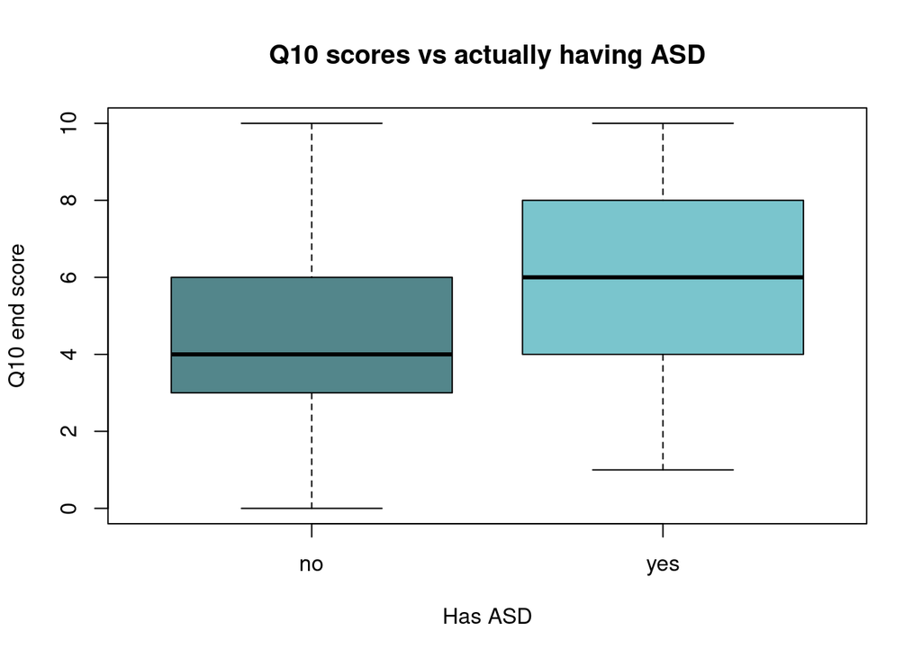

```r
boxplot(data$end_score ~ data$autism, col=c("cadetblue4", "cadetblue3"), xlab="Has ASD", ylab="Q10 end score", main="Q10 scores vs actually having ASD")
```

```r
t.test(data$end_score, subset=data$autism, var.equal = TRUE)
```

```
##
##  One Sample t-test
##
## data:  data$end_score
## t = 51.867, df = 700, p-value < 2.2e-16
## alternative hypothesis: true mean is not equal to 0
## 95 percent confidence interval:
##  4.703675 5.073785
## sample estimates:
## mean of x
##   4.88873
```

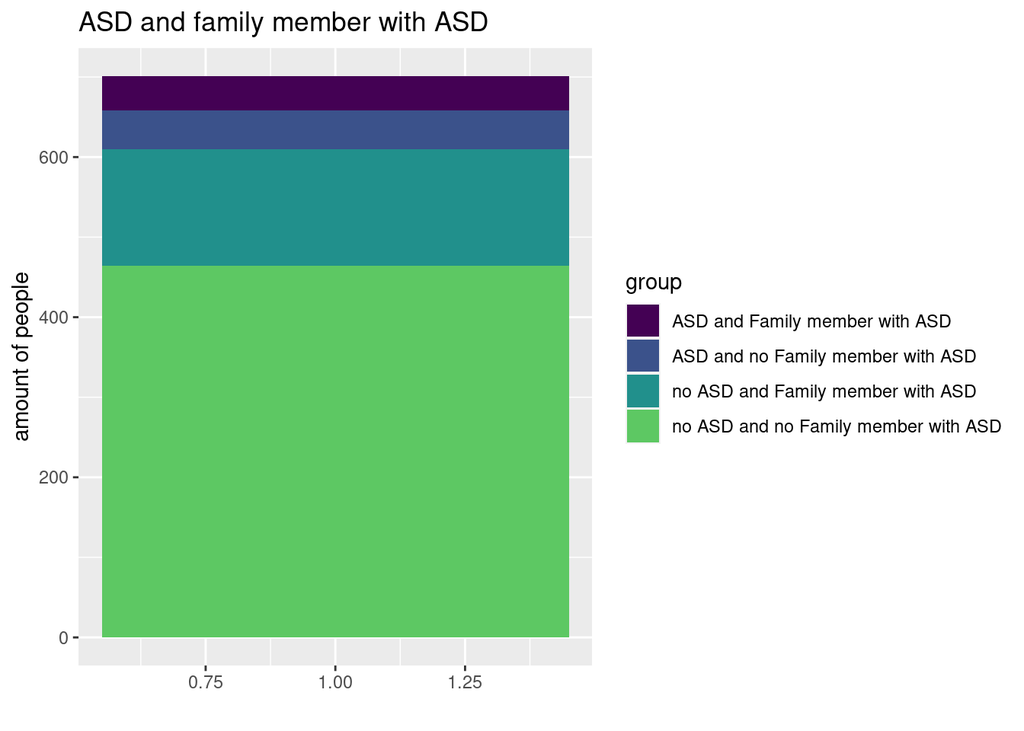

```r
df <- data.frame(x = rep(1, each=4),
                   y = rep(0, each=4),
                   group = c("ASD and Family member with ASD", "ASD and no Family member with ASD", "no ASD and Family member with ASD", "no ASD and no Family member with ASD"))

df$y <- c(sum(data$class_asd == "YES" & data$autism == "yes"), sum(data$class_asd == "NO" & data$autism == "yes"),
          sum(data$class_asd == "YES" & data$autism == "no"), sum(data$class_asd == "NO" & data$autism == "no"))

ggp <- ggplot(df, aes(x = x, y = y, fill = group, label = y)) +  # Create stacked bar chart
  geom_bar(stat = "identity") + ggtitle("ASD and family member with ASD") + xlab("") + ylab("amount of people") + scale_fill_manual(values = viridis(5))
ggp
```

Figure 4, This figure shows that Most people that take the test do not have ASD and no family member with ASD. There’s also a big part of the group that do not have ASD but have family members with ASD. This makes sense because these people probably want to take the test because they know they have a family member with ASD and are scared they have it too.

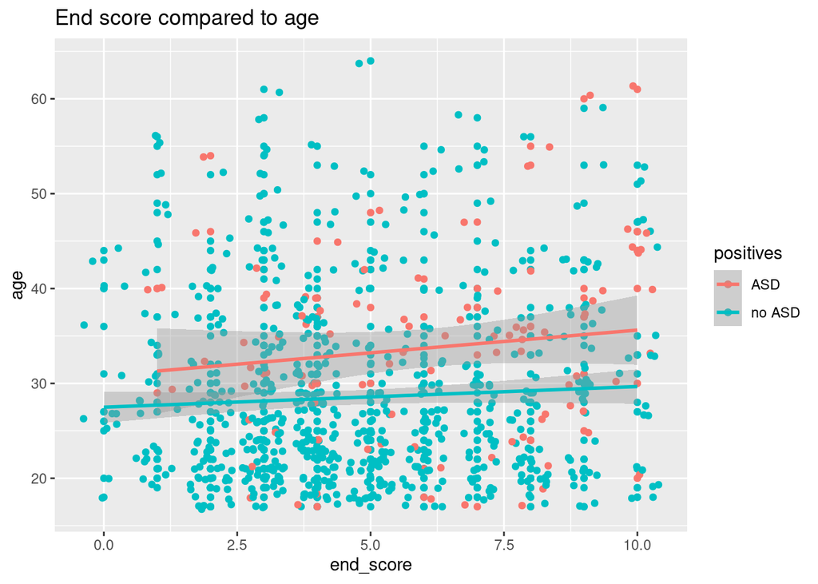

```r
grouped <- data %>%
  mutate(positives = case_when(
    autism == "yes" ~ "ASD",
    autism == "no" ~ "no ASD"
  ))
ggplot(grouped, aes(x = end_score, y = age, colour = positives)) +
  geom_point() + geom_jitter() + ggtitle("End score compared to age") + geom_smooth(method="lm")
```

```r
cor.test(data$end_score, data$age, method="pearson")
```

```
##
##  Pearson's product-moment correlation
##
## data:  data$end_score and data$age
## t = 2.5981, df = 699, p-value = 0.009571
## alternative hypothesis: true correlation is not equal to 0
## 95 percent confidence interval:
##  0.02392249 0.17061353
## sample estimates:
##        cor
## 0.09779918
```

## The weka algorithm

There needs to be a algorithm made in Weka. After entering the data and removing the unused parts (Country of birth, Country of residence, Used the app before) multiple algorithms were tested. The function algorithm “SimpleLogistic” is chosen. This one fits the most because the different variables do not have a correlation therefore a tree or decision algorithm would not work. After having tested this algorithm the results were dissapointing. Even though the % predicted right was a high 75%, the algorithm almost always predicted that people didn’t have autism. Which seems good because not a lot of people have it. But the goal is to know when people have ASD. After concluding this i realized that the data was imbalanced. This was fixed by using a ClassBalancer supervised filter. Now the ASD values are 350.5 350.5 instead of 507 194. Now that the algorithm is correct some statistical tests will be applied.

[output not shown]

### Threshold curve

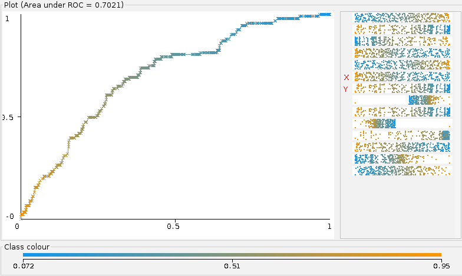